# Pre-lab Question 2

Your Ronchi ruling consists of a series of long parallel slits (slit width $b$, period $a$). Monochromatic light incident on the object diffracts and forms a far-field (Fraunhofer) diffraction pattern.

**(a)** Derive Eq. (32) for the far-field diffraction intensity pattern of $N$ slits.

**(b)** Make sample plots for different values of $N$ and $a$, and describe qualitatively how each parameter affects:

- the spacing between diffraction orders,
- the width of diffraction peaks,
- and the overall envelope of the pattern.

**(c)** Explore the effect of varying the duty cycle $b/a$. How does it affect the relative intensity of diffraction orders (including which orders may be suppressed)?

**(d)** In the experiment, diffraction orders will not be perfectly sharp and may broaden with order. Briefly explain at least two physical reasons why a real diffraction pattern may deviate from the ideal prediction of Eq. (32). (Hint: consider finite source size, finite spectral bandwidth, and imperfect alignment/aberrations.)

**Eq. (32):** $$ I(\theta) = I_0 \left( \frac{\sin\beta}{\beta} \right)^2 \left( \frac{\sin(N\alpha)}{N\sin(\alpha)} \right)^2 $$

Where: $$ \alpha = \frac{k a \sin \theta}{2}, \quad \beta = \frac{k b \sin \theta}{2}, \quad k = \frac{2 \pi}{\lambda} $$

## B)

Make sample plots for different values of N and a, and describe qualitatively how each parameter affects: • the spacing between diffraction orders, • the width of diffraction peaks, • and the overall envelope of the pattern.

$$I(\theta) \propto \left(\frac{\sin(N\alpha)}{N\sin(\alpha)}\right)^2 $$

```python
import matplotlib.pyplot as plt
plt.style.use('dark_background')
import numpy as np
```

Note:

Here a is the grating period of the Ronchi ruling and b is the slit width (close to b = a/2, but it may differ slightly). (LabScript: Pg 11)

```python
def I(theta, N, a, lam=None, I0=1.0):
    """
    theta : array of angles (rad)
    N     : number of slits
    a     : grating period (m)
    lam   : wavelength (m), default 525 nm
    I0    : overall I scale
    """

    lam = (lam or 525) # nm (Lab Script Pg 22)
    lam = lam * 10**(-9) # m
    b = a/2 #  (Lab Script Pg 11 and inspired by code in Pg 12)

    k = 2*np.pi / lam
    alpha = 0.5 * k * a * np.sin(theta)
    beta  = 0.5 * k * b * np.sin(theta)

    single_slit = (np.sin(beta) / beta)**2
    interference = (np.sin(N*alpha) / (N*np.sin(alpha)))**2

    return I0 * single_slit * interference
```

i) Keeping **a** constant, Changing N

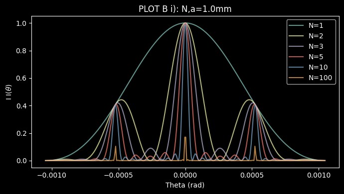

```python
theta = np.linspace(-np.pi/3000,np.pi/3000,300)
N_lst = [1,2,3,5,10,100] # different numbers of slits
a_lst = [1,10,100,1000] # mm

# Keeping a constant, Changing N
#plt.subplot(1,2,1)
plt.figure(figsize=(7,4))
for i in range(len(N_lst)):
    a = a_lst[0]
    a = a * 10**(-3) # m
    #plt.subplot(len(N_lst),2,i+1)
    # sharex = True
    plt.plot(theta, I(theta,N=N_lst[i],a=a) , label=f"N={N_lst[i]}",alpha=0.7)

plt.title(f"PLOT B i): N,a={a*1000}mm")
plt.xlabel("Theta (rad)")
plt.ylabel(r"I I$(\theta)$")
plt.legend()
plt.tight_layout()
plt.show()
```

ii) Vary **a** at fixed **N**

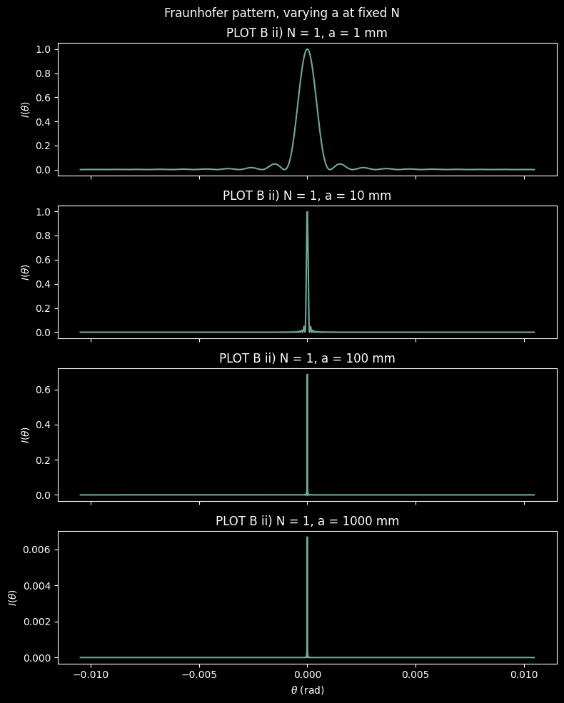

```python
theta = np.linspace(-np.pi/300,np.pi/300,3000)
plt.figure(figsize=(16,8))

N = N_lst[0]

fig, axs = plt.subplots(len(a_lst), 1, figsize=(8, 10), sharex=True)

for i, a_mm in enumerate(a_lst):
    a = a_mm * 1e-3  # convert mm -> m
    I_vals = I(theta, N=N, a=a)

    axs[i].plot(theta, I_vals, alpha=0.8)
    axs[i].set_ylabel(r"$I(\theta)$")
    axs[i].set_title(f"PLOT B ii) N = {N}, a = {a_mm} mm")

axs[-1].set_xlabel(r"$\theta$ (rad)")
fig.suptitle("Fraunhofer pattern, varying a at fixed N", y=0.98)
fig.tight_layout()
plt.show()
```

iii) Grid

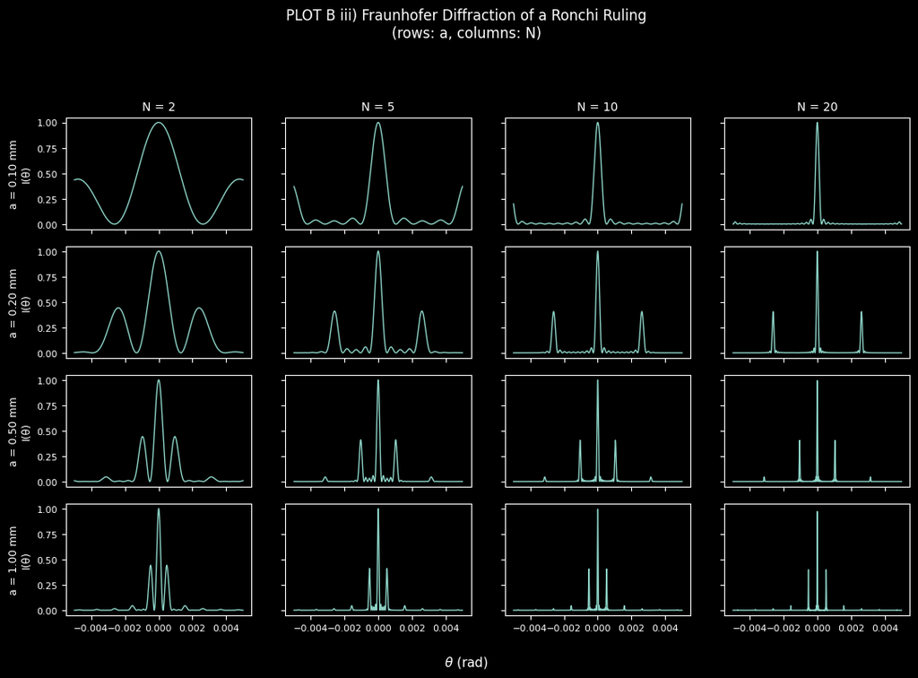

```python
# Angle range (rad) – chosen to show several diffraction orders
theta = np.linspace(-5e-3, 5e-3, 2000)   # ~±0.3 degrees

# Columns: different N
N_list = [2, 5, 10, 20]

# Rows: different grating periods a (in mm)
a_list_mm = [0.1, 0.2, 0.5, 1.0]  # adjust to taste

# ----------------------------------------
# Create grid of plots: rows = a, cols = N
# ----------------------------------------

n_rows = len(a_list_mm)
n_cols = len(N_list)

# A4 in landscape: about 11.69 x 8.27 inches
fig, axes = plt.subplots(
    n_rows,
    n_cols,
    figsize=(11.69, 8.27),
    sharex=True,
    sharey=True
)

# If there's only one row/col, make axes always 2D-indexable
axes = np.atleast_2d(axes)

for i, a_mm in enumerate(a_list_mm):
    a_m = a_mm * 1e-3  # convert mm -> m
    for j, N in enumerate(N_list):

        ax = axes[i, j]
        I_vals = I(theta, N=N, a=a_m)

        ax.plot(theta, I_vals, lw=1.0)

        # Top row: label with N
        if i == 0:
            ax.set_title(f"N = {N}", fontsize=10)

        # First column: label with a
        if j == 0:
            ax.set_ylabel(f"a = {a_mm:.2f} mm\nI(θ)", fontsize=9)

        # Keep ticks small so everything fits nicely
        ax.tick_params(axis='both', which='both', labelsize=8)

# Common x-label
fig.text(0.5, 0.04, r"$\theta$ (rad)", ha='center', fontsize=11)

# Optional overall title
fig.suptitle("PLOT B iii) Fraunhofer Diffraction of a Ronchi Ruling\n(rows: a, columns: N)", fontsize=12)

# Make layout tight for A4 printing
fig.tight_layout(rect=[0.03, 0.07, 0.97, 0.93])

# Optional: save for printing
# plt.savefig("ronchi_grid_A4.pdf", dpi=300, bbox_inches="tight")

plt.show()
```

**Fraunhofer Diffraction of a Ronchi Ruling: Effect of Slit Number $N$ and Period $a$**

Each panel shows the normalized far-field intensity $I(\theta)$ for a 1D Ronchi ruling, modeled as a grating of $N$ identical slits with period $a$ and duty cycle $b/a = 0.5$ (i.e., slit width $b = a/2$).

Rows correspond to different grating periods **$a$** (in mm), and columns correspond to different numbers of illuminated slits **$N$**. The diffraction pattern is computed from the standard N-slit Fraunhofer formula:

$$I(\theta) \propto \underbrace{\left[ \frac{\sin(\beta)}{\beta} \right]^2}_{\text{single-slit envelope}} \times \underbrace{\left[ \frac{\sin(N\alpha)}{N\sin(\alpha)} \right]^2}_{\text{N-slit interference}}$$

### Variables Defined:

- $\alpha = \frac{1}{2} k a \sin\theta$
- $\beta = \frac{1}{2} k b \sin\theta$
- $k = 2\pi / \lambda$
- $\lambda = 525 \text{ nm}$

## Key Qualitative Features

- **Effect of increasing $N$ (across columns):** The principal maxima become narrower and sharper, and the side lobes (subsidiary maxima) become more numerous but relatively weaker. This matches the behavior of the interference term: $[\sin(N\alpha) / (N\sin\alpha)]^2$.
- **Effect of increasing $a$ (down rows):** The angular spacing between diffraction orders decreases approximately as $\Delta\theta \sim \lambda/a$. Larger periods produce more closely spaced peaks.
- **Single-slit envelope:** The overall envelope is set by $[\sin(\beta) / \beta]^2$. This broadens when $b$ is smaller and narrows when $b$ is larger. For a fixed duty cycle $b = a/2$, changing $a$ simultaneously rescales both the order spacing and the envelope width.

## Assumptions and Simplifications

| Category | Description |
| --- | --- |
| **Regime** | **Fraunhofer (far-field)**: The pattern is the Fourier transform of the aperture; no Fresnel-region effects. |
| **Geometry** | **Scalar & 1D**: Polarization, finite slit height, and 2D structures are ignored. |
| **Light Source** | **Perfectly Coherent**: Single wavelength $\lambda = 525 \text{ nm}$ with no spectral bandwidth. |
| **Optics** | **Idealized**: No lens aberrations, misalignment, detector noise, or finite pixel size. |
| **Normalization** | **Per-subplot**: Intensities are normalized to their own maximum for shape comparison. |

> **Note:** Under these idealized assumptions, the plots isolate the pure dependence of the Fraunhofer diffraction pattern on the grating period $a$ and the number of illuminated slits $N$.

### c)

Effect of varying the duty cycle b/a. How it affects the relative intensity of diffraction orders (including which orders may be suppressed).

and Vary the duty, b/a

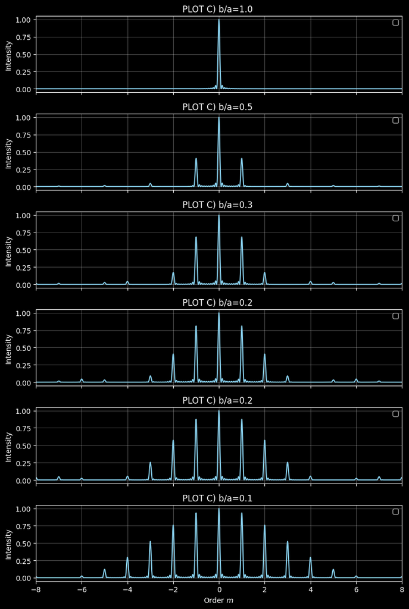

```python
import numpy as np
import matplotlib.pyplot as plt
from fractions import Fraction as frac


def I_var_ba(theta, N, a, b_by_a, lam_nm=525, I0=1.0):
    """
    Calculates Fraunhofer intensity using the np.sinc identity.
    np.sinc(x) is defined as sin(pi*x)/(pi*x).
    """
    lam = lam_nm * 1e-9
    # s is the 'order' coordinate: (a*sin(theta))/lambda
    # When s is an integer, we are at an interference maximum.
    s = (a * np.sin(theta)) / lam

    # 1. Single Slit Envelope
    # Nulls occur when (b*sin(theta))/lambda is an integer.
    # This is equivalent to s * (b/a) being an integer.
    envelope = np.sinc(s * b_by_a)**2

    # 2. Interference Pattern
    # This identity avoids division by zero at sin(theta) = 0.
    # It normalizes the peak height to 1.0.
    interference = (np.sinc(N * s) / np.sinc(s))**2

    return I0 * envelope * interference

# --- Parameters ---
lam_nm = 525
N      = 10
a_mm   = 0.20
a      = a_mm * 1e-3

# Define duty cycles (b/a). b must be <= a.
b_by_a_list = [1.0, 1/2, 1/3, 1/4, 1/5,1/7]
theta = np.linspace(-np.pi/120, np.pi/120, 5000)

fig, axs = plt.subplots(len(b_by_a_list), 1, figsize=(8, 12),sharex=True)

for i, b_by_a in enumerate(b_by_a_list):
    I_vals = I_var_ba(theta, N, a, b_by_a, lam_nm)

    # Convert theta to 's' for the plot to see integer orders clearly
    s_vals = (a * np.sin(theta)) / (lam_nm * 1e-9)

    axs[i].plot(s_vals, I_vals, color='skyblue')
    axs[i].set_ylabel("Intensity")
    axs[i].legend(loc='upper right')
    axs[i].grid(alpha=0.3)
    axs[i].set_title(f"PLOT C) b/a={b_by_a:.1f} ")

    # Highlight where orders SHOULD be (integer s)
    # If a peak is missing at an integer s, you've found a missing order!



axs[-1].set_xlabel(r"Order $m$ ")
plt.xlim(-8, 8)
plt.tight_layout()
plt.show()
```